# campo asociativo en chile

redeslab

Septiembre 2021

# 1 Librerías

```r
pacman::p_load(intergraph,
               tidygraph,
               igraph,
               network,
               signnet,
               sna,
               MASS,
               ggplot2,
               xlsx,
               ggraph,
               backbone,
               dplyr,
               readr,
               reshape2,
               extrafont,
               kableExtra,
               table1,
               flextable,
               tigerstats,
               foreign,
               xtable,
               Hmisc,
               memisc,
               nnet,
               lattice,
               texreg)
```

```
##
##  C:\Users\rober\AppData\Local\Temp\RtmpWibep0\downloaded_packages
```

# 2 Manipulación de la data

## 2.1 Cargar data

```r
#2016
load("C:/Users/rober/Desktop/ELSOC/ELSOC_W01_v4.01_R (3).RData")
#2018
load("C:/Users/rober/Desktop/ELSOC/ELSOC_W03_v2.00_R.RData")
```

## 2.2 Recod 2016-2018

```r
asociaciones_2016 <- elsoc_2016 %>%
  dplyr::mutate (JJVV         = ifelse(c12_01>=2, 1, 0)) %>%
  dplyr::mutate (Religiosa    = ifelse(c12_02>=2, 1, 0)) %>%
  dplyr::mutate (Partido      = ifelse(c12_03>=2, 1, 0)) %>%
  dplyr::mutate (Deportiva    = ifelse(c12_07>=2, 1, 0)) %>%
  dplyr::mutate (AAEE         = ifelse(c12_08>=2, 1, 0)) %>%
  dplyr::mutate (Caridad      = ifelse(c12_06>=2, 1, 0)) %>%
  dplyr::mutate (Sindicato    = ifelse(c12_04>=2, 1, 0)) %>%
  dplyr::mutate (Profesional  = ifelse(c12_05>=2, 1, 0)) %>%
  dplyr::mutate (Otras        = ifelse(c12_09>=2, 1, 0))%>%
  dplyr::select (JJVV, Religiosa, AAEE, Deportiva, Partido,
                 Profesional, Sindicato, Caridad, Otras)

asociaciones_2018 <- elsoc_2018 %>%
  dplyr::filter(muestra==1)%>% #seleccionar casos de la muestra original
  dplyr::mutate (JJVV         = ifelse(c12_01>=2, 1, 0)) %>%
  dplyr::mutate (Religiosa    = ifelse(c12_02>=2, 1, 0)) %>%
  dplyr::mutate (Partido      = ifelse(c12_03>=2, 1, 0)) %>%
  dplyr::mutate (Deportiva    = ifelse(c12_07>=2, 1, 0)) %>%
  dplyr::mutate (AAEE         = ifelse(c12_08>=2, 1, 0)) %>%
  dplyr::mutate (Caridad      = ifelse(c12_06>=2, 1, 0)) %>%
  dplyr::mutate (Sindicato    = ifelse(c12_04>=2, 1, 0)) %>%
  dplyr::mutate (Profesional  = ifelse(c12_05>=2, 1, 0)) %>%
  dplyr::mutate (Otras        = ifelse(c12_09>=2, 1, 0))%>%
  dplyr::select (JJVV, Religiosa, AAEE, Deportiva, Partido,
                 Profesional, Sindicato, Caridad, Otras)
```

## 2.3 NA

```r
asociaciones_2016[asociaciones_2016=="-999"] <- NA
asociaciones_2016[asociaciones_2016=="-888"] <- NA
asociaciones_2018[asociaciones_2018=="-999"] <- NA
asociaciones_2018[asociaciones_2018=="-888"] <- NA
```

# 3 Descriptivos (composición de las asociaciones)

```r
asociaciones_2016d <- elsoc_2016 %>%
  dplyr::mutate (JJVV         = ifelse(c12_01<2, 0, 1)) %>%
  dplyr::mutate (Religiosa    = ifelse(c12_02<2, 0, 1)) %>%
  dplyr::mutate (Partido      = ifelse(c12_03<2, 0, 1)) %>%
  dplyr::mutate (Deportiva    = ifelse(c12_07<2, 0, 1)) %>%
  dplyr::mutate (AAEE         = ifelse(c12_08<2, 0, 1)) %>%
  dplyr::mutate (Caridad      = ifelse(c12_06<2, 0, 1)) %>%
  dplyr::mutate (Sindicato    = ifelse(c12_04<2, 0, 1)) %>%
  dplyr::mutate (Profesional  = ifelse(c12_05<2, 0, 1)) %>%
  dplyr::mutate (Otras        = ifelse(c12_09<2, 0, 1))%>%
  dplyr::mutate (mujer        = case_when(m0_sexo   == 1     ~ "hombre",
                                          m0_sexo   == 2     ~ "mujer")) %>%
  dplyr::mutate (edad         = case_when(m0_edad %in% 18:29 ~ "joven",
                                          m0_edad %in% 30:65 ~ "adulto",
                                          m0_edad %in% 66:88 ~ "adulto_mayor")) %>%
  dplyr::mutate (nivel_educ   = case_when(m01     %in% 1 :7  ~ "no_univers",
                                          m01     %in% 8 :10 ~ "univers"))%>%
  dplyr::select(JJVV,Religiosa,Partido,Deportiva,AAEE,Caridad,Sindicato,
                Profesional,Otras,mujer,edad,nivel_educ)%>%
  as.data.frame()


asociaciones_2018d <- elsoc_2018 %>%
  dplyr::mutate (JJVV         = ifelse(c12_01<2, 0, 1)) %>%
  dplyr::mutate (Religiosa    = ifelse(c12_02<2, 0, 1)) %>%
  dplyr::mutate (Partido      = ifelse(c12_03<2, 0, 1)) %>%
  dplyr::mutate (Deportiva    = ifelse(c12_07<2, 0, 1)) %>%
  dplyr::mutate (AAEE         = ifelse(c12_08<2, 0, 1)) %>%
  dplyr::mutate (Caridad      = ifelse(c12_06<2, 0, 1)) %>%
  dplyr::mutate (Sindicato    = ifelse(c12_04<2, 0, 1)) %>%
  dplyr::mutate (Profesional  = ifelse(c12_05<2, 0, 1)) %>%
  dplyr::mutate (Otras        = ifelse(c12_09<2, 0, 1))%>%
  dplyr::mutate (mujer        = case_when(m0_sexo   == 1     ~ "hombre",
                                          m0_sexo   == 2     ~ "mujer")) %>%
  dplyr::mutate (edad         = case_when(m0_edad %in% 18:29 ~ "joven",
                                          m0_edad %in% 30:65 ~ "adulto",
                                          m0_edad %in% 66:88 ~ "adulto_mayor")) %>%
  dplyr::mutate (nivel_educ   = case_when(m01     %in% 1 :7  ~ "no_univers",
                                          m01     %in% 8 :10 ~ "univers"))%>%
  dplyr::select(JJVV,Religiosa,Partido,Deportiva,AAEE,Caridad,Sindicato,
                Profesional,Otras,mujer,edad,nivel_educ)%>%
  as.data.frame()
```

## 3.1 subtablas 2016

```r
t1<-rowPerc(xtabs(~JJVV+mujer,data=asociaciones_2016d))
t2<-rowPerc(xtabs(~Religiosa+mujer,data=asociaciones_2016d))
t3<-rowPerc(xtabs(~Deportiva+mujer,data=asociaciones_2016d))
t4<-rowPerc(xtabs(~Caridad+mujer,data=asociaciones_2016d))
t5<-rowPerc(xtabs(~Partido+mujer,data=asociaciones_2016d))
t6<-rowPerc(xtabs(~Profesional+mujer,data=asociaciones_2016d))
t7<-rowPerc(xtabs(~Sindicato+mujer,data=asociaciones_2016d))
t8<-rowPerc(xtabs(~AAEE+mujer,data=asociaciones_2016d))
t9<-rowPerc(xtabs(~Otras+mujer,data=asociaciones_2016d))

a<-rbind(t1,t2,t3,t4,t5,t6,t7,t8,t9)
a<-as.data.frame(a)
a$part<-c(0,1,0,1,0,1,0,1,0,1,0,1,0,1,0,1,0,1)
a1<-a[a$part==1,]

a1$Tipo<-c("JJVV","Religiosa","Deportiva","Caridad","Partido","Profesional","Sindicato","AAEE","Otras")
a1<-a1%>%
  dplyr::select(Tipo,hombre,mujer)
#a1
```

```r
t1<-rowPerc(xtabs(~JJVV+nivel_educ,data=asociaciones_2016d))
t2<-rowPerc(xtabs(~Religiosa+nivel_educ,data=asociaciones_2016d))
t3<-rowPerc(xtabs(~Deportiva+nivel_educ,data=asociaciones_2016d))
t4<-rowPerc(xtabs(~Caridad+nivel_educ,data=asociaciones_2016d))
t5<-rowPerc(xtabs(~Partido+nivel_educ,data=asociaciones_2016d))
t6<-rowPerc(xtabs(~Profesional+nivel_educ,data=asociaciones_2016d))
t7<-rowPerc(xtabs(~Sindicato+nivel_educ,data=asociaciones_2016d))
t8<-rowPerc(xtabs(~AAEE+nivel_educ,data=asociaciones_2016d))
t9<-rowPerc(xtabs(~Otras+nivel_educ,data=asociaciones_2016d))

a<-rbind(t1,t2,t3,t4,t5,t6,t7,t8,t9)
a<-as.data.frame(a)
a$part<-c(0,1,0,1,0,1,0,1,0,1,0,1,0,1,0,1,0,1)
a2<-a[a$part==1,]
a2<-a2%>%
  dplyr::select("no universitario"=no_univers, "universitario"=univers)
```

```r
t1<-rowPerc(xtabs(~JJVV+edad,data=asociaciones_2016d))
t2<-rowPerc(xtabs(~Religiosa+edad,data=asociaciones_2016d))
t3<-rowPerc(xtabs(~Deportiva+edad,data=asociaciones_2016d))
t4<-rowPerc(xtabs(~Caridad+edad,data=asociaciones_2016d))
t5<-rowPerc(xtabs(~Partido+edad,data=asociaciones_2016d))
t6<-rowPerc(xtabs(~Profesional+edad,data=asociaciones_2016d))
t7<-rowPerc(xtabs(~Sindicato+edad,data=asociaciones_2016d))
t8<-rowPerc(xtabs(~AAEE+edad,data=asociaciones_2016d))
t9<-rowPerc(xtabs(~Otras+edad,data=asociaciones_2016d))

a<-rbind(t1,t2,t3,t4,t5,t6,t7,t8,t9)
a<-as.data.frame(a)
a$part<-c(0,1,0,1,0,1,0,1,0,1,0,1,0,1,0,1,0,1)
a3<-a[a$part==1,]
a3<-a3%>%
  dplyr::select(joven, adulto, "adulto mayor"=adulto_mayor)
```

## 3.2 Descriptivos 2016

```r
tabla1<-cbind(a1,a2,a3)
tabla1<-as.data.frame(tabla1)
tabla1<-tibble::rowid_to_column(tabla1, "id")

tabla1 %>%
  kbl(caption = "Composición (%) de participantes en asociaciones voluntarias (ELSOC 2016)") %>%
    kable_classic("hover", full_width = F)
```

Composición (%) de participantes en asociaciones voluntarias (ELSOC 2016)

| id | Tipo | hombre | mujer | no universitario | universitario | joven | adulto | adulto mayor |
| --- | --- | --- | --- | --- | --- | --- | --- | --- |
| 1 | JJVV | 32.39 | 67.61 | 86.44 | 13.56 | 7.58 | 74.76 | 17.66 |
| 2 | Religiosa | 32.14 | 67.86 | 84.67 | 15.33 | 12.16 | 69.16 | 18.68 |
| 3 | Deportiva | 64.52 | 35.48 | 74.94 | 25.06 | 24.81 | 67.49 | 7.69 |
| 4 | Caridad | 36.56 | 63.44 | 71.90 | 28.10 | 11.78 | 71.60 | 16.62 |
| 5 | Partido | 50.00 | 50.00 | 66.44 | 33.56 | 16.00 | 71.33 | 12.67 |
| 6 | Profesional | 45.98 | 54.02 | 55.36 | 44.64 | 11.16 | 80.36 | 8.48 |
| 7 | Sindicato | 52.15 | 47.85 | 78.55 | 21.45 | 16.17 | 78.55 | 5.28 |
| 8 | AAEE | 37.40 | 62.60 | 60.31 | 39.69 | 31.30 | 63.36 | 5.34 |
| 9 | Otras | 27.73 | 72.27 | 78.15 | 21.85 | 16.81 | 59.66 | 23.53 |

## 3.3 subtablas 2018

```r
t1<-rowPerc(xtabs(~JJVV+mujer,data=asociaciones_2018d))
t2<-rowPerc(xtabs(~Religiosa+mujer,data=asociaciones_2018d))
t3<-rowPerc(xtabs(~Deportiva+mujer,data=asociaciones_2018d))
t4<-rowPerc(xtabs(~Caridad+mujer,data=asociaciones_2018d))
t5<-rowPerc(xtabs(~Partido+mujer,data=asociaciones_2018d))
t6<-rowPerc(xtabs(~Profesional+mujer,data=asociaciones_2018d))
t7<-rowPerc(xtabs(~Sindicato+mujer,data=asociaciones_2018d))
t8<-rowPerc(xtabs(~AAEE+mujer,data=asociaciones_2018d))
t9<-rowPerc(xtabs(~Otras+mujer,data=asociaciones_2018d))

a<-rbind(t1,t2,t3,t4,t5,t6,t7,t8,t9)
a<-as.data.frame(a)
#a
a$part<-c(0,1,0,1,0,1,0,1,0,1,0,1,0,1,0,1,0,1)
a1<-a[a$part==1,]

a1$Tipo<-c("JJVV","Religiosa","Deportiva","Caridad","Partido","Profesional","Sindicato","AAEE","Otras")
a1<-a1%>%
  dplyr::select(Tipo,hombre,mujer)
#a1
```

```r
t1<-rowPerc(xtabs(~JJVV+nivel_educ,data=asociaciones_2018d))
t2<-rowPerc(xtabs(~Religiosa+nivel_educ,data=asociaciones_2018d))
t3<-rowPerc(xtabs(~Deportiva+nivel_educ,data=asociaciones_2018d))
t4<-rowPerc(xtabs(~Caridad+nivel_educ,data=asociaciones_2018d))
t5<-rowPerc(xtabs(~Partido+nivel_educ,data=asociaciones_2018d))
t6<-rowPerc(xtabs(~Profesional+nivel_educ,data=asociaciones_2018d))
t7<-rowPerc(xtabs(~Sindicato+nivel_educ,data=asociaciones_2018d))
t8<-rowPerc(xtabs(~AAEE+nivel_educ,data=asociaciones_2018d))
t9<-rowPerc(xtabs(~Otras+nivel_educ,data=asociaciones_2018d))

a<-rbind(t1,t2,t3,t4,t5,t6,t7,t8,t9)
a<-as.data.frame(a)
a$part<-c(0,1,0,1,0,1,0,1,0,1,0,1,0,1,0,1,0,1)
a2<-a[a$part==1,]
a2<-a2%>%
  dplyr::select("no universitario"=no_univers, "universitario"=univers)
#a2
```

```r
t1<-rowPerc(xtabs(~JJVV+edad,data=asociaciones_2018d))
t2<-rowPerc(xtabs(~Religiosa+edad,data=asociaciones_2018d))
t3<-rowPerc(xtabs(~Deportiva+edad,data=asociaciones_2018d))
t4<-rowPerc(xtabs(~Caridad+edad,data=asociaciones_2018d))
t5<-rowPerc(xtabs(~Partido+edad,data=asociaciones_2018d))
t6<-rowPerc(xtabs(~Profesional+edad,data=asociaciones_2018d))
t7<-rowPerc(xtabs(~Sindicato+edad,data=asociaciones_2018d))
t8<-rowPerc(xtabs(~AAEE+edad,data=asociaciones_2018d))
t9<-rowPerc(xtabs(~Otras+edad,data=asociaciones_2018d))

a<-rbind(t1,t2,t3,t4,t5,t6,t7,t8,t9)
a<-as.data.frame(a)
a$part<-c(0,1,0,1,0,1,0,1,0,1,0,1,0,1,0,1,0,1)
a3<-a[a$part==1,]
a3<-a3%>%
  dplyr::select(joven, adulto, "adulto mayor"=adulto_mayor)
#a3
```

## 3.4 Descriptivos 2018

```r
tabla1<-cbind(a1,a2,a3)
tabla1<-as.data.frame(tabla1)
tabla1<-tibble::rowid_to_column(tabla1, "id")

tabla1 %>%
  kbl(caption = "Composición (%) de participantes en asociaciones voluntarias (ELSOC 2018)") %>%
    kable_classic("hover", full_width = F)
```

Composición (%) de participantes en asociaciones voluntarias (ELSOC 2018)

| id | Tipo | hombre | mujer | no universitario | universitario | joven | adulto | adulto mayor |
| --- | --- | --- | --- | --- | --- | --- | --- | --- |
| 1 | JJVV | 31.72 | 68.28 | 83.89 | 16.11 | 8.82 | 73.14 | 18.04 |
| 2 | Religiosa | 31.91 | 68.09 | 85.09 | 14.91 | 10.99 | 69.72 | 19.28 |
| 3 | Deportiva | 67.05 | 32.95 | 73.66 | 26.34 | 21.90 | 70.86 | 7.24 |
| 4 | Caridad | 40.57 | 59.43 | 69.82 | 30.18 | 11.89 | 71.93 | 16.19 |
| 5 | Partido | 54.14 | 45.86 | 65.19 | 34.81 | 18.23 | 67.96 | 13.81 |
| 6 | Profesional | 51.18 | 48.82 | 51.78 | 48.22 | 16.14 | 72.44 | 11.42 |
| 7 | Sindicato | 49.18 | 50.82 | 78.69 | 21.31 | 18.03 | 77.60 | 4.37 |
| 8 | AAEE | 40.95 | 59.05 | 65.24 | 34.76 | 33.81 | 60.95 | 5.24 |
| 9 | Otras | 35.29 | 64.71 | 71.90 | 28.10 | 11.76 | 62.09 | 26.14 |

## 3.5 `as.matrix`

```r
#asociaciones_2016 <- na.omit(asociaciones_2016)
asociaciones_2016 <- as.matrix(asociaciones_2016)

#asociaciones_2018 <- na.omit(asociaciones_2018)
asociaciones_2018 <- as.matrix(asociaciones_2018)
```

# 4 Modelos de extracción de vínculos significativos con `Backbone`

El enfoque que el backbone está diseñado para identificar los vínculos importantes que se retendrán en el “backbone” mediante una prueba estadística que compara el peso observado de un vínculo con la distribución de sus pesos bajo un modelo nulo.

Dado un modelo nulo que puede generar una distribución de los pesos de un borde $G^*_{ij}$, es posible calcular la probabilidad de que el peso observado de un borde esté en la parte superior $(P(G^*_{ij}\geq G_{ij}))$ o en la cola inferior $(P(G^*_{ij}\leqq G_{ij}))$ de esta distribución y, por lo tanto, no es probable que sea el resultado de un modelo nulo. Usando estas probabilidades y un nivel de significancia $α$ para la prueba, se puede extraer una columna vertebral “signada” de manera que:

$$G_{ij}= \left\{\begin{array}{lr}
1 & \text{si } P(G^*_{ij}\geq G_{ij} )<\alpha/2\\
-1 & \text{si } P(G^*_{ij}\leq G_{ij} )<\alpha/2\\
0 & \text{de otra manera }
\end{array}\right\}$$

En otros casos puede ser de utilidad una matriz binaria que excluya los valores negativos, de manera que:

$$G_{ij}= \left\{\begin{array}{lr}
1 & \text{si } P(G^*_{ij}\geq G_{ij} )<\alpha/2\\
0 & \text{si } P(G^*_{ij}\geq G_{ij} )\geq\alpha/2\\
\end{array}\right\}$$

Ya sea que se extraiga matriz (bakcbone) binaria o con signo, se usa una prueba de significancia tro tailed porque, para cualquier lazo dado, el valor observado en la proyección podría estar en cualquier cola de la distribución nula.

El enfoque estadístico para la extracción de la columna vertebral radica en definir un modelo nulo adecuado y calcular las probabilidades requeridas (es decir, valores p de lazos). Una familia de nueve modelos nulos se puede definir por las restricciones que colocan en las sumas de filas y columnas en un gráfico bipartito aleatorio $B^*$: Las sumas de filas en $B^*$, y por separado las sumas de columnas en $B^*$, pueden ser ilimitadas, restringidas a coincidir con los valores de $B$ en promedio, o restringido a coincidir exactamente con los valores de $B$.

Sea R un conjunto de restricciones en los grados de vértice de las filas y columnas correspondientes a una de estas nueve posibilidades, y sea $B(R)$ el espacio de todos los gráficos bipartitos $B^*$ que satisfacen esas condiciones. Este enfoque de extracción de la columna vertebral compara los valores $G_{ij}$, la proyección bipartita de interés, con las distribuciones que describen $G^*_{ij}=(B^*B^{*T})_{ij}$ para todos los gráficos bipartitos $B^*\in B(R)$. Aquí, nos enfocamos en tres conjuntos de restricciones $B(R)$, definiendo tres modelos nulos distintos: (1) el modelo hipergeométrico, en el que las sumas de las filas están restringidas para coincidir exactamente con las de $B$, pero las sumas de las columnas no están restringidas; (2) el modelo de secuencia de grados estocásticos, en el que las sumas de filas y columnas están restringidas para coincidir con las de $B$ en promedio; y (3) el modo de secuencia de grados fijos, en el que las sumas de filas y columnas están restringidas para coincidir exactamente con las de $B$.

El modelo trabajado acá es el modelo de secuencia de grados fijos. A continuacón detallamos el procedimiento para su estimación.

# 5 Modelo secuencial de grados fijos (FDSM)

El modelo secuencial de grados fijos restringe las sumas de filas y columnas en $B^*$ para que sean iguales a sus valores en $B$ (es decir, ambas son fijas) (Zweig & Kaufmann, 2011). La distribución de probabilidad que describe $(B^* B^{*T})_{ij}$ para todas las gráficas bipartitas $B^* \in B(R)$ se desconoce y, por lo tanto, se construye una distribución aproximada mediante simulación:

1. Se construye un gráfico bipartito $B^*$ que represente un sorteo aleatorio de $B(R)$
2. Proyecta $B^*$ (es decir, calcular $B^*B^{*T}$) para obtener una proyección bipartita ponderada aleatoria $G^*$.
3. Repetir los pasos 1 y 2 N veces para muestrear el espacio de posible $G^*_{ij}$.

La multiplicación de matrices requerida en el paso 2 es computacionalmente costosa pero sencilla. Sin embargo, el muestreo aleatorio de un $B^*$ de $B(R)$ en el paso 1 es más desafiante. Se han sugerido varios métodos, incluidos los métodos de intercambio de Markov (Gionis et al., 2007) y el muestreo de importancia secuencial (Chen et al., 2005). Aquí utilizamos el algoritmo curveball (Strona et al., 2014), que es uno de los algoritmos más rápidos que se ha demostrado que funciona aleatoriamente.

# 6 Backbone 2016

```r
#Transpose
asociaciones_2016t <-t(asociaciones_2016)

#Proyección modo 1 (overlap)
overlap_2016 <- asociaciones_2016t%*%t(asociaciones_2016t)
#write.xlsx (overlap_2016, file = "overlap_2016.xlsx")

## Hyperg model
hyperg_2016 <- hyperg(asociaciones_2016t)
hyperg_bb_2016 <- backbone.extract(hyperg_2016, signed = TRUE)
hyperg_bb_2016
```

```
##             JJVV Religiosa AAEE Deportiva Partido Profesional Sindicato Caridad
## JJVV           0         1    0        -1       1          -1        -1       0
## Religiosa      1         0    0        -1       0          -1        -1       1
## AAEE           0         0    0         1       1           1         1       1
## Deportiva     -1        -1    1         0       0           0         1       1
## Partido        1         0    1         0       0           1         1       1
## Profesional   -1        -1    1         0       1           0         1       1
## Sindicato     -1        -1    1         1       1           1         0       1
## Caridad        0         1    1         1       1           1         1       0
## Otras          0        -1    1         0       0           0         0       1
##             Otras
## JJVV            0
## Religiosa      -1
## AAEE            1
## Deportiva       0
## Partido         0
## Profesional     0
## Sindicato       0
## Caridad         1
## Otras           0
```

```r
## Stochastic Degree Sequence Model
sdsm_2016 <- sdsm(asociaciones_2016t)
sdsm_bb_2016 <- backbone.extract(sdsm_2016, signed = TRUE, alpha = 0.05)
sdsm_bb_2016
```

```
##             JJVV Religiosa AAEE Deportiva Partido Profesional Sindicato Caridad
## JJVV           0        -1   -1        -1      -1          -1        -1      -1
## Religiosa     -1         0   -1        -1      -1          -1        -1      -1
## AAEE          -1        -1    0         0       0           0        -1       0
## Deportiva     -1        -1    0         0      -1          -1        -1      -1
## Partido       -1        -1    0        -1       0           0         0       0
## Profesional   -1        -1    0        -1       0           0         0       0
## Sindicato     -1        -1   -1        -1       0           0         0       0
## Caridad       -1        -1    0        -1       0           0         0       0
## Otras         -1        -1   -1        -1      -1          -1        -1      -1
##             Otras
## JJVV           -1
## Religiosa      -1
## AAEE           -1
## Deportiva      -1
## Partido        -1
## Profesional    -1
## Sindicato      -1
## Caridad        -1
## Otras           0
```

```r
## Fixed Degree Sequence Model
fdsm_2016  <- fdsm(asociaciones_2016t, trials = 10000)
fdsm_2016a <- fdsm(asociaciones_2016t, trials = 10000, dyad = c("Religiosa", "JJVV"))
fdsm_2016b <- fdsm(asociaciones_2016t, trials = 10000, dyad = c("Religiosa", "Sindicato"))
```

## 6.1 Extraccción bakcbone

```r
fdsm_bb_2016 <- backbone.extract(fdsm_2016, signed = TRUE, alpha = 0.01)
fdsm_bb_2016
```

```
##             JJVV Religiosa AAEE Deportiva Partido Profesional Sindicato Caridad
## JJVV           0         1    0        -1       0          -1        -1       0
## Religiosa      1         0    0        -1       0          -1        -1       1
## AAEE           0         0    0         1       1           0         0       1
## Deportiva     -1        -1    1         0       0           0         0       0
## Partido        0         0    1         0       0           1         0       1
## Profesional   -1        -1    0         0       1           0         1       1
## Sindicato     -1        -1    0         0       0           1         0       0
## Caridad        0         1    1         0       1           1         0       0
## Otras         -1        -1    0        -1       0           0        -1       0
##             Otras
## JJVV           -1
## Religiosa      -1
## AAEE            0
## Deportiva      -1
## Partido         0
## Profesional     0
## Sindicato      -1
## Caridad         0
## Otras           0
```

```r
#class(fdsm_2016)
```

## 6.2 Graficar distribución aleatoria (sim) y valores observados)

### 6.2.1 Diada Religiosas/JJVV

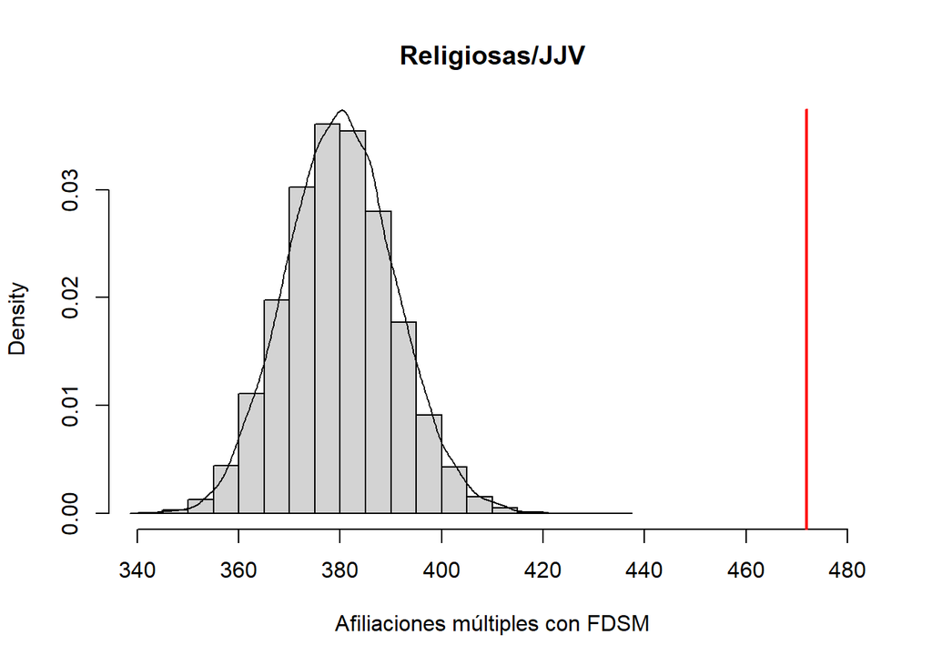

```r
hist(fdsm_2016a$dyad_values,
     freq = FALSE,
     xlim=c(340,480),
     main="Religiosas/JJV",
     xlab = "Afiliaciones múltiples con FDSM")
lines(density(fdsm_2016a$dyad_values))
abline(v=472,col="red",lwd=2)
```

### 6.2.2 Diada Religiosas/Sindicatos

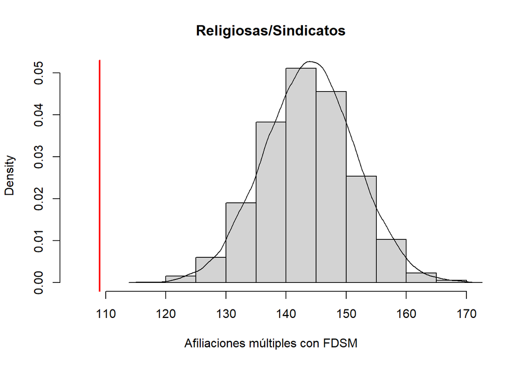

```r
hist(fdsm_2016b$dyad_values,
     freq = FALSE,
     xlim=c(105,170),
     main="Religiosas/Sindicatos",
     xlab = "Afiliaciones múltiples con FDSM")
lines(density(fdsm_2016b$dyad_values))
abline(v=109,col="red",lwd=2)
```

## 6.3 matrix -> edgelist con `melt`

```r
matrix2016 <- as.matrix(fdsm_bb_2016)
bb_2016_e  <-melt(matrix2016)%>%
  dplyr::na_if("value"==0)%>%
  dplyr::select(from=Var2, to=Var1,sign=value)%>%
  na.omit()

bb_2016_e$year<-2016
bb_2016_e
```

```
##           from          to sign year
## 2         JJVV   Religiosa    1 2016
## 4         JJVV   Deportiva   -1 2016
## 6         JJVV Profesional   -1 2016
## 7         JJVV   Sindicato   -1 2016
## 9         JJVV       Otras   -1 2016
## 10   Religiosa        JJVV    1 2016
## 13   Religiosa   Deportiva   -1 2016
## 15   Religiosa Profesional   -1 2016
## 16   Religiosa   Sindicato   -1 2016
## 17   Religiosa     Caridad    1 2016
## 18   Religiosa       Otras   -1 2016
## 22        AAEE   Deportiva    1 2016
## 23        AAEE     Partido    1 2016
## 26        AAEE     Caridad    1 2016
```

[output cut: 24 more lines]

# 7 Backbone 2018

```r
# Transpose
asociaciones_2018t <-t(asociaciones_2018)

# Proyección modo 1 (overlap)
overlap_2018 <- asociaciones_2018t%*%t(asociaciones_2018t)
#write.xlsx (overlap_2018, file = "overlap_2018.xlsx")

## Hyperg model
hyperg_2018 <- hyperg(asociaciones_2018t)
hyperg_bb_2018 <- backbone.extract(hyperg_2018, signed = TRUE)
hyperg_bb_2018
```

```
##             JJVV Religiosa AAEE Deportiva Partido Profesional Sindicato Caridad
## JJVV           0         0    0        -1       1           0         0       0
## Religiosa      0         0    0        -1       1           0        -1       0
## AAEE           0         0    0         1       1           1         1       1
## Deportiva     -1        -1    1         0       1           1         1       1
## Partido        1         1    1         1       0           1         1       1
## Profesional    0         0    1         1       1           0         1       1
## Sindicato      0        -1    1         1       1           1         0       1
## Caridad        0         0    1         1       1           1         1       0
## Otras          0        -1    0         0       0           0         0       0
##             Otras
## JJVV            0
## Religiosa      -1
## AAEE            0
## Deportiva       0
## Partido         0
## Profesional     0
## Sindicato       0
## Caridad         0
## Otras           0
```

```r
## Stochastic Degree Sequence Model
sdsm_2018 <- sdsm(asociaciones_2018t)
sdsm_bb_2018 <- backbone.extract(sdsm_2018, signed = TRUE, alpha = 0.05)
sdsm_bb_2018
```

```
##             JJVV Religiosa AAEE Deportiva Partido Profesional Sindicato Caridad
## JJVV           0        -1   -1        -1       0          -1        -1      -1
## Religiosa     -1         0   -1        -1       0          -1        -1      -1
## AAEE          -1        -1    0         0       0           0         0       0
## Deportiva     -1        -1    0         0       0           0        -1       0
## Partido        0         0    0         0       0           1         0       0
## Profesional   -1        -1    0         0       1           0         1       0
## Sindicato     -1        -1    0        -1       0           1         0      -1
## Caridad       -1        -1    0         0       0           0        -1       0
## Otras         -1        -1   -1        -1      -1          -1        -1      -1
##             Otras
## JJVV           -1
## Religiosa      -1
## AAEE           -1
## Deportiva      -1
## Partido        -1
## Profesional    -1
## Sindicato      -1
## Caridad        -1
## Otras           0
```

```r
## Fixed Degree Sequence Model
fdsm_2018  <- fdsm(asociaciones_2018t, trials = 10000)
fdsm_2018a <- fdsm(asociaciones_2018t, trials = 10000, dyad = c("Religiosa", "JJVV"))
fdsm_2018b <- fdsm(asociaciones_2018t, trials = 10000, dyad = c("Religiosa", "Sindicato"))
```

## 7.1 Extraccción `bakcbone`

```r
fdsm_bb_2018 <- backbone.extract(fdsm_2018, signed = TRUE, alpha = 0.01)
fdsm_bb_2018
```

```
##             JJVV Religiosa AAEE Deportiva Partido Profesional Sindicato Caridad
## JJVV           0         1    0        -1       0           0         0       0
## Religiosa      1         0    0        -1       0           0        -1       0
## AAEE           0         0    0         1       0           0         0       1
## Deportiva     -1        -1    1         0       0           0         0       0
## Partido        0         0    0         0       0           1         0       1
## Profesional    0         0    0         0       1           0         1       1
## Sindicato      0        -1    0         0       0           1         0       0
## Caridad        0         0    1         0       1           1         0       0
## Otras         -1        -1   -1        -1       0          -1        -1      -1
##             Otras
## JJVV           -1
## Religiosa      -1
## AAEE           -1
## Deportiva      -1
## Partido         0
## Profesional    -1
## Sindicato      -1
## Caridad        -1
## Otras           0
```

```r
#class(fdsm_2016)
```

## 7.2 Graficar distribución aleatoria (sim) y valores observados)

### 7.2.1 Diada Religiosas/JJVV

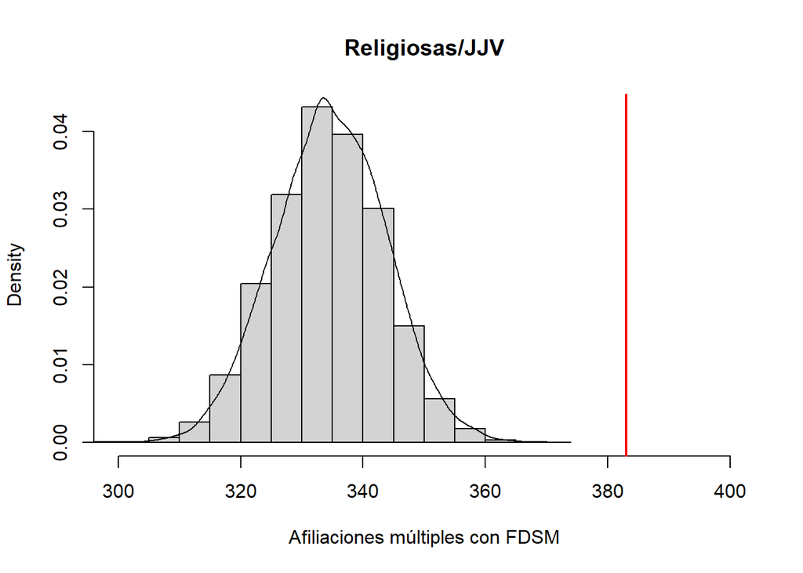

```r
hist(fdsm_2018a$dyad_values,
     freq = FALSE,
     xlim=c(300,400),
     main="Religiosas/JJV",
     xlab = "Afiliaciones múltiples con FDSM")
lines(density(fdsm_2018a$dyad_values))
abline(v=383,col="red",lwd=2)
```

### 7.2.2 Diada Religiosas/Sindicatos

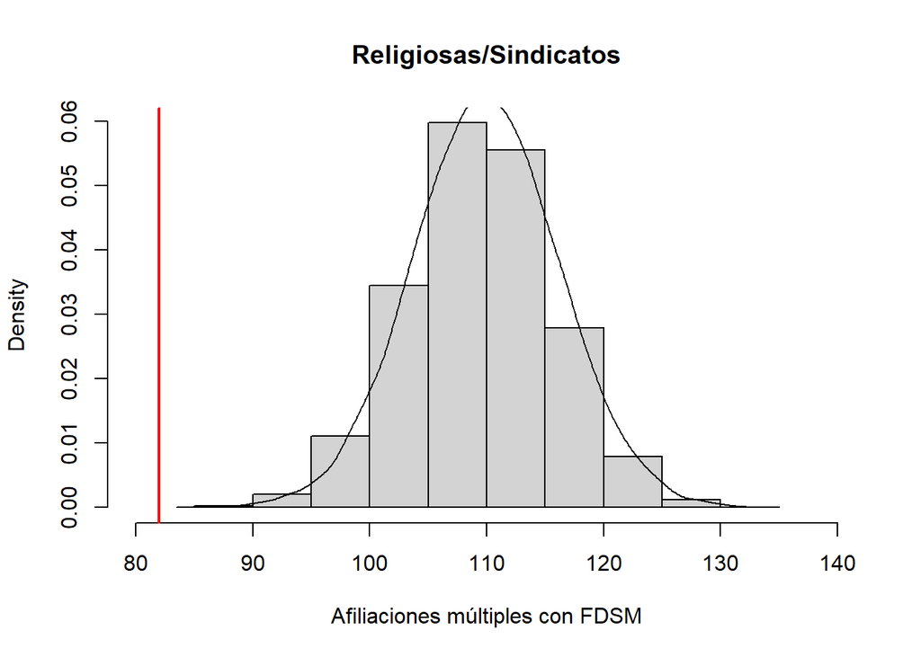

```r
hist(fdsm_2018b$dyad_values,
     freq = FALSE,
     xlim=c(80,140),
     main="Religiosas/Sindicatos",
     xlab = "Afiliaciones múltiples con FDSM")
lines(density(fdsm_2018b$dyad_values))
abline(v=82,col="red",lwd=2)
```

## 7.3 matrix -> edgelist con `melt`

```r
matrix2018 <- as.matrix(fdsm_bb_2018)
bb_2018_e  <-melt(matrix2018)%>%
  dplyr::na_if("value"==0)%>%
  dplyr::select(from=Var2, to=Var1,sign=value)%>%
  na.omit()

bb_2018_e$year<-2018
bb_2018_e
```

```
##           from          to sign year
## 2         JJVV   Religiosa    1 2018
## 4         JJVV   Deportiva   -1 2018
## 9         JJVV       Otras   -1 2018
## 10   Religiosa        JJVV    1 2018
## 13   Religiosa   Deportiva   -1 2018
## 16   Religiosa   Sindicato   -1 2018
## 18   Religiosa       Otras   -1 2018
## 22        AAEE   Deportiva    1 2018
## 26        AAEE     Caridad    1 2018
## 27        AAEE       Otras   -1 2018
## 28   Deportiva        JJVV   -1 2018
## 29   Deportiva   Religiosa   -1 2018
## 30   Deportiva        AAEE    1 2018
## 36   Deportiva       Otras   -1 2018
```

[output cut: 20 more lines]

# 8 Graficar campo asociativo 2016-2018

## 8.1 agregamos data con `rbind`

```r
g<-rbind(bb_2016_e,bb_2018_e)
g
```

```
##            from          to sign year
## 2          JJVV   Religiosa    1 2016
## 4          JJVV   Deportiva   -1 2016
## 6          JJVV Profesional   -1 2016
## 7          JJVV   Sindicato   -1 2016
## 9          JJVV       Otras   -1 2016
## 10    Religiosa        JJVV    1 2016
## 13    Religiosa   Deportiva   -1 2016
## 15    Religiosa Profesional   -1 2016
## 16    Religiosa   Sindicato   -1 2016
## 17    Religiosa     Caridad    1 2016
## 18    Religiosa       Otras   -1 2016
## 22         AAEE   Deportiva    1 2016
## 23         AAEE     Partido    1 2016
## 26         AAEE     Caridad    1 2016
```

[output cut: 58 more lines]

## 8.2 crear vector link

```r
g <- graph_from_data_frame(g, directed = F)

E(g)[E(g)$sign ==  "1"]$link <- "attraction"
E(g)[E(g)$sign == "-1"]$link <- "repulsion"
```

## 8.3 Plot

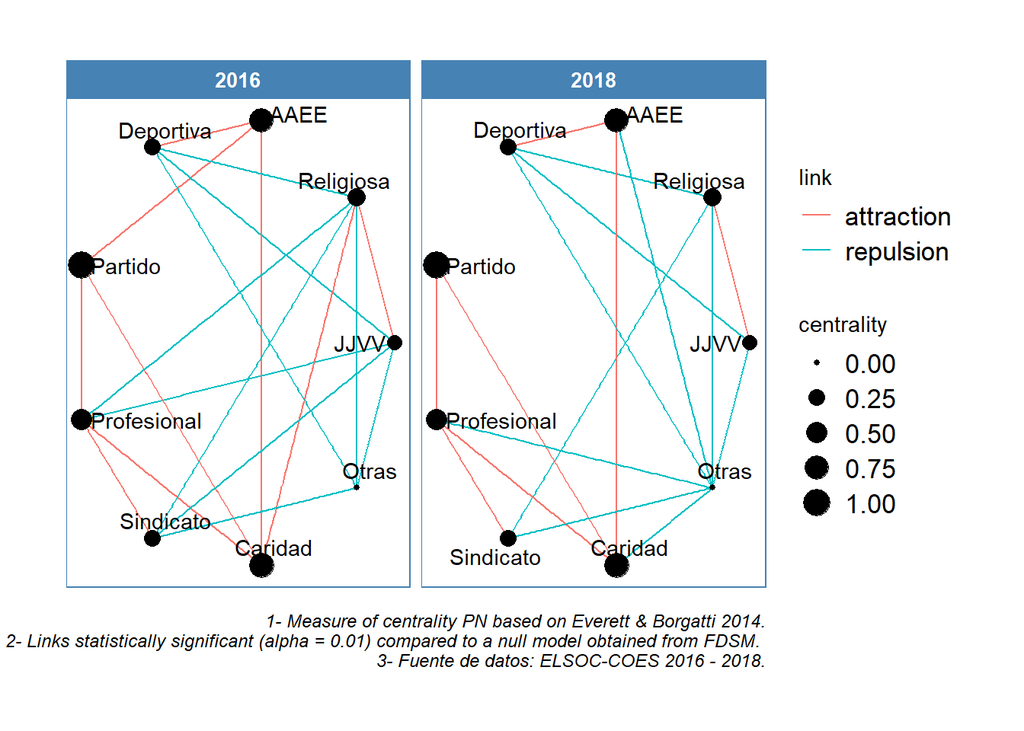

```r
#extrafont::font_import()
#extrafont::loadfonts()

# agregar atributos a la red
g$name <- "Red asociativa"
#g$name

V(g)$id <- 1:9
#V(g)$id
#V(g)$tipo

## Calcular degree signed "ratio":  positive neighbors/(positive neighbors+negative neighbors)/
V(g)$centrality<-degree_signed(g, type="ratio")

# Visualización de la red
p1<-ggraph(g, layout = "in_circle") +
      theme_graph(background = "white",
              base_family = "Helvetica",
              foreground = 'steelblue',
              fg_text_colour = 'white',
              base_size = 11) +
     geom_edge_link(aes(color = link)) +
     geom_node_point(aes(size = centrality),alpha = 8) +
     geom_node_text(aes(label = name), repel = T) +
# geom_edge_density(aes(fill = vinculo)) +
     geom_edge_link(alpha = 0.001) +
     facet_edges(~year) +
     theme(legend.text=element_text(size=13)) +
     labs(caption = "1- Measure of centrality PN based on Everett & Borgatti 2014.
     2- Links statistically significant (alpha = 0.01) compared to a null model obtained from FDSM.
     3- Fuente de datos: ELSOC-COES 2016 - 2018.")

p1
```

```r
#?theme
#ggraph:::igraphlayouts
```

# 9 Análisis de balance estructural con `Signnet`

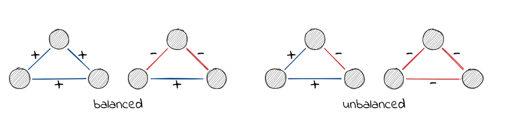

## 9.1 triangulos (balance)

```r
g_sign<-rbind(bb_2016_e,bb_2018_e)
```

### 9.1.1 2016

```r
t_2016<-g_sign%>%
  dplyr::filter(year==2016)

t_2016<-graph_from_data_frame(t_2016,directed = F)
#E(t_2016)$sign
tb_2016<-count_signed_triangles(t_2016)
tb_2016<-as.data.frame(tb_2016)
#tb_2016
```

### 9.1.2 2018

```r
t_2018<-g_sign%>%
  dplyr::filter(year==2018)

t_2018<-graph_from_data_frame(t_2018,directed = F)
#E(t_2016)$sign
tb_2018<-count_signed_triangles(t_2018)
tb_2018<-as.data.frame(tb_2018)
#tb_2018
```

### 9.1.3 Tabla

```r
tt<-cbind(tb_2016,tb_2018)
tt<-as.data.frame(tt)

tt %>%
  kbl(caption = "Balance 2016-2018") %>%
  kable_paper("hover", full_width = F)
```

Balance 2016-2018

|  | tb_2016 | tb_2018 |
| --- | --- | --- |
| +++ | 2 | 1 |
| ++- | 1 | 0 |
| +– | 6 | 6 |
| — | 4 | 3 |

El predominio de estructuras locales balanceadas sugiere una tendencia a la estabilidad del campo organizacional.

## 9.2 Balancedness (polarización)

### 9.2.1 2016

```r
triangles  <-balance_score(t_2016, method = "triangles")
walk       <-balance_score(t_2016, method = "walk")
frustration<-balance_score(t_2016, method = "frustration")

b2016<-cbind(triangles,walk,frustration)
b2016<-as.data.frame(b2016)

b2016$year<-2016
#b2016
```

### 9.2.2 2018

```r
triangles  <-balance_score(t_2018, method = "triangles")
walk       <-balance_score(t_2018, method = "walk")
frustration<-balance_score(t_2018, method = "frustration")

b2018<-cbind(triangles,walk,frustration)
b2018<-as.data.frame(b2018)

b2018$year<-2018
#b2018
```

## 9.3 tabla

```r
bb<-rbind(b2016,b2018)
bb<-as.data.frame(bb)

bb %>%
  kbl(caption = "Blancedness 2016-2018") %>%
  kable_paper("hover", full_width = F)
```

Blancedness 2016-2018

| triangles | walk | frustration | year |
| --- | --- | --- | --- |
| 0.6153846 | 0.1613770 | 1 | 2016 |
| 0.7000000 | 0.2844786 | 1 | 2018 |

Las estructuras balanceadas cuando se puede dividir en dos subconjuntos de vértices, de modo que las aristas intragrupo sean todas positivas y las aristas intergrupales sean todas negativas. Los resultados anteriores, muestran una tendencia a la polarización fuerte en el campo considerando los análisis de Neal (2020). Para nuestro análisis esto es indicativo de una fragmentación vertical del campo de la sociedad civil.

# 10 Análisis de regresión

```r
#cargar librerias
library(sjmisc)
#Cargar base de datos desde el repositorio de Dataverse
load(url("https://dataverse.harvard.edu/api/access/datafile/4606527"))
elsoc<-elsoc_wide_2016_2019

#REVISAR ESTO
#frq(elsoc$c12_01_w01)
#with(elsoc, table(c12_01_w01,c12_01_w03))

#filtrar base de datos
elsoc<- elsoc_wide_2016_2019 %>% dplyr::filter(muestra==1)
#elsoc<- elsoc_wide_2016_2019 %>% filter(tipo_atricion<=2 | tipo_atricion==6)
#frq(elsoc$tipo_atricion)

#recodificar variables
elsoc <- elsoc %>%
  dplyr::mutate (JJVV_w01         = ifelse(c12_01_w01>=2, 1, 0)) %>%
  dplyr::mutate (Religiosa_w01    = ifelse(c12_02_w01>=2, 1, 0)) %>%
  dplyr::mutate (Partido_w01      = ifelse(c12_03_w01>=2, 1, 0)) %>%
  dplyr::mutate (Deportiva_w01    = ifelse(c12_07_w01>=2, 1, 0)) %>%
  dplyr::mutate (AAEE_w01         = ifelse(c12_08_w01>=2, 1, 0)) %>%
  dplyr::mutate (Caridad_w01      = ifelse(c12_06_w01>=2, 1, 0)) %>%
  dplyr::mutate (Sindicato_w01    = ifelse(c12_04_w01>=2, 1, 0)) %>%
  dplyr::mutate (Profesional_w01  = ifelse(c12_05_w01>=2, 1, 0)) %>%
  dplyr::mutate (Otras_w01        = ifelse(c12_09_w01>=2, 1, 0)) %>%
  dplyr::mutate (JJVV_w03         = ifelse(c12_01_w03>=2, 1, 0)) %>%
  dplyr::mutate (Religiosa_w03    = ifelse(c12_02_w03>=2, 1, 0)) %>%
  dplyr::mutate (Partido_w03      = ifelse(c12_03_w03>=2, 1, 0)) %>%
  dplyr::mutate (Deportiva_w03    = ifelse(c12_07_w03>=2, 1, 0)) %>%
  dplyr::mutate (AAEE_w03         = ifelse(c12_08_w03>=2, 1, 0)) %>%
  dplyr::mutate (Caridad_w03      = ifelse(c12_06_w03>=2, 1, 0)) %>%
  dplyr::mutate (Sindicato_w03    = ifelse(c12_04_w03>=2, 1, 0)) %>%
  dplyr::mutate (Profesional_w03  = ifelse(c12_05_w03>=2, 1, 0)) %>%
  dplyr::mutate (Otras_w03        = ifelse(c12_09_w03>=2, 1, 0))


elsoc$JJVV_tray        <- paste0(elsoc$JJVV_w01,elsoc$JJVV_w03)
elsoc$Religiosa_tray   <- paste0(elsoc$Religiosa_w01,elsoc$Religiosa_w03)
elsoc$Partido_tray     <- paste0(elsoc$Partido_w01,elsoc$Partido_w03)
elsoc$Deportiva_tray   <- paste0(elsoc$Deportiva_w01,elsoc$Deportiva_w03)
elsoc$AAEE_tray        <- paste0(elsoc$AAEE_w01,elsoc$AAEE_w03)
elsoc$Caridad_tray     <- paste0(elsoc$Caridad_w01,elsoc$Caridad_w03)
elsoc$Sindicato_tray   <- paste0(elsoc$Sindicato_w01,elsoc$Sindicato_w03)
elsoc$Profesional_tray <- paste0(elsoc$Profesional_w01,elsoc$Profesional_w03)
elsoc$Otras_tray       <- paste0(elsoc$Otras_w01,elsoc$Otras_w03)

#frq(elsoc$JJVV_tray)
#frq(elsoc$Religiosa_tray)
#frq(elsoc$Partido_tray)
#frq(elsoc$Deportiva_tray)
#frq(elsoc$AAEE_tray)
#frq(elsoc$Caridad_tray)
#frq(elsoc$Sindicato_tray)
#frq(elsoc$Profesional_tray)
#frq(elsoc$Otras_tray)

elsoc$JJVV_tray       <- car::recode(elsoc$JJVV_tray,       "'00'='NP';'01'='CP';'10'='DP';'11'='MP'; else=NA", as.factor = T)
elsoc$Religiosa_tray  <- car::recode(elsoc$Religiosa_tray,  "'00'='NP';'01'='CP';'10'='DP';'11'='MP'; else=NA", as.factor = T)
elsoc$Partido_tray    <- car::recode(elsoc$Partido_tray,    "'00'='NP';'01'='CP';'10'='DP';'11'='MP'; else=NA", as.factor = T)
elsoc$Deportiva_tray  <- car::recode(elsoc$Deportiva_tray,  "'00'='NP';'01'='CP';'10'='DP';'11'='MP'; else=NA", as.factor = T)
elsoc$AAEE_tray       <- car::recode(elsoc$AAEE_tray,       "'00'='NP';'01'='CP';'10'='DP';'11'='MP'; else=NA", as.factor = T)
elsoc$Caridad_tray    <- car::recode(elsoc$Caridad_tray,    "'00'='NP';'01'='CP';'10'='DP';'11'='MP'; else=NA", as.factor = T)
elsoc$Sindicato_tray  <- car::recode(elsoc$Sindicato_tray,  "'00'='NP';'01'='CP';'10'='DP';'11'='MP'; else=NA", as.factor = T)
elsoc$Profesional_tray<- car::recode(elsoc$Profesional_tray,"'00'='NP';'01'='CP';'10'='DP';'11'='MP'; else=NA", as.factor = T)
elsoc$Otras_tray      <- car::recode(elsoc$Otras_tray,      "'00'='NP';'01'='CP';'10'='DP';'11'='MP'; else=NA", as.factor = T)

#CPDP
lab = c("NP","CP","DP","MP")

elsoc$JJVV_tray       <- factor(elsoc$JJVV_tray       ,labels = lab)
elsoc$Religiosa_tray  <- factor(elsoc$Religiosa_tray  ,labels = lab)
elsoc$Partido_tray    <- factor(elsoc$Partido_tray    ,labels = lab)
elsoc$Deportiva_tray  <- factor(elsoc$Deportiva_tray  ,labels = lab)
elsoc$AAEE_tray       <- factor(elsoc$AAEE_tray       ,labels = lab)
elsoc$Caridad_tray    <- factor(elsoc$Caridad_tray    ,labels = lab)
elsoc$Sindicato_tray  <- factor(elsoc$Sindicato_tray  ,labels = lab)
elsoc$Profesional_tray<- factor(elsoc$Profesional_tray,labels = lab)
elsoc$Otras_tray      <- factor(elsoc$Otras_tray      ,labels = lab)


frq(elsoc$JJVV_tray)
```

```
##
## x <categorical>
## # total N=2928  valid N=2228  mean=3.08  sd=1.11
##
## Value |    N | Raw % | Valid % | Cum. %
## ---------------------------------------
## NP    |  329 | 11.24 |   14.77 |  14.77
## CP    |  308 | 10.52 |   13.82 |  28.59
## DP    |  445 | 15.20 |   19.97 |  48.56
## MP    | 1146 | 39.14 |   51.44 | 100.00
## <NA>  |  700 | 23.91 |    <NA> |   <NA>
```

```r
frq(elsoc$Religiosa_tray)
```

```
##
## x <categorical>
## # total N=2928  valid N=2228  mean=3.15  sd=1.09
##
## Value |    N | Raw % | Valid % | Cum. %
## ---------------------------------------
## NP    |  295 | 10.08 |   13.24 |  13.24
## CP    |  289 |  9.87 |   12.97 |  26.21
## DP    |  433 | 14.79 |   19.43 |  45.65
## MP    | 1211 | 41.36 |   54.35 | 100.00
## <NA>  |  700 | 23.91 |    <NA> |   <NA>
```

```r
frq(elsoc$Partido_tray)
```

```
##
## x <categorical>
## # total N=2928  valid N=2228  mean=3.80  sd=0.68
##
## Value |    N | Raw % | Valid % | Cum. %
## ---------------------------------------
## NP    |   81 |  2.77 |    3.64 |   3.64
## CP    |   93 |  3.18 |    4.17 |   7.81
## DP    |   27 |  0.92 |    1.21 |   9.02
## MP    | 2027 | 69.23 |   90.98 | 100.00
## <NA>  |  700 | 23.91 |    <NA> |   <NA>
```

```r
frq(elsoc$Deportiva_tray)
```

```
##
## x <categorical>
## # total N=2928  valid N=2228  mean=3.56  sd=0.93
##
## Value |    N | Raw % | Valid % | Cum. %
## ---------------------------------------
## NP    |  169 |  5.77 |    7.59 |   7.59
## CP    |  181 |  6.18 |    8.12 |  15.71
## DP    |  122 |  4.17 |    5.48 |  21.18
## MP    | 1756 | 59.97 |   78.82 | 100.00
## <NA>  |  700 | 23.91 |    <NA> |   <NA>
```

```r
frq(elsoc$AAEE_tray)
```

```
##
## x <categorical>
## # total N=2928  valid N=2228  mean=3.79  sd=0.70
##
## Value |    N | Raw % | Valid % | Cum. %
## ---------------------------------------
## NP    |   94 |  3.21 |    4.22 |   4.22
## CP    |   83 |  2.83 |    3.73 |   7.94
## DP    |   18 |  0.61 |    0.81 |   8.75
## MP    | 2033 | 69.43 |   91.25 | 100.00
## <NA>  |  700 | 23.91 |    <NA> |   <NA>
```

```r
frq(elsoc$Caridad_tray)
```

```
##
## x <categorical>
## # total N=2928  valid N=2228  mean=3.52  sd=0.99
##
## Value |    N | Raw % | Valid % | Cum. %
## ---------------------------------------
## NP    |  215 |  7.34 |    9.65 |   9.65
## CP    |  174 |  5.94 |    7.81 |  17.46
## DP    |   80 |  2.73 |    3.59 |  21.05
## MP    | 1759 | 60.08 |   78.95 | 100.00
## <NA>  |  700 | 23.91 |    <NA> |   <NA>
```

```r
frq(elsoc$Sindicato_tray)
```

```
##
## x <categorical>
## # total N=2928  valid N=2228  mean=3.68  sd=0.81
##
## Value |    N | Raw % | Valid % | Cum. %
## ---------------------------------------
## NP    |  118 |  4.03 |    5.30 |   5.30
## CP    |  137 |  4.68 |    6.15 |  11.45
## DP    |   95 |  3.24 |    4.26 |  15.71
## MP    | 1878 | 64.14 |   84.29 | 100.00
## <NA>  |  700 | 23.91 |    <NA> |   <NA>
```

```r
frq(elsoc$Profesional_tray)
```

```
##
## x <categorical>
## # total N=2928  valid N=2228  mean=3.75  sd=0.74
##
## Value |    N | Raw % | Valid % | Cum. %
## ---------------------------------------
## NP    |   98 |  3.35 |    4.40 |   4.40
## CP    |  107 |  3.65 |    4.80 |   9.20
## DP    |   55 |  1.88 |    2.47 |  11.67
## MP    | 1968 | 67.21 |   88.33 | 100.00
## <NA>  |  700 | 23.91 |    <NA> |   <NA>
```

```r
frq(elsoc$Otras_tray)
```

```
##
## x <categorical>
## # total N=2928  valid N=2228  mean=3.82  sd=0.66
##
## Value |    N | Raw % | Valid % | Cum. %
## ---------------------------------------
## NP    |   80 |  2.73 |    3.59 |   3.59
## CP    |   73 |  2.49 |    3.28 |   6.87
## DP    |   21 |  0.72 |    0.94 |   7.81
## MP    | 2054 | 70.15 |   92.19 | 100.00
## <NA>  |  700 | 23.91 |    <NA> |   <NA>
```

# 11 Recod

```r
elsoc<-elsoc%>%
  dplyr::mutate(mujer=as.factor(case_when(m0_sexo_w01==1~"hombre",
                                          m0_sexo_w01==2~"mujer")))%>%
  dplyr::mutate(mujer=as.factor(case_when(m0_sexo_w03==1~"hombre",
                                          m0_sexo_w03==2~"mujer")))%>%
  dplyr::mutate(edad =as.factor(case_when (m0_edad_w01%in%18:24~"18-24",
                                           m0_edad_w01%in%25:34~"25-34",
                                           m0_edad_w01%in%34:44~"34-44",
                                           m0_edad_w01%in%45:54~"45-54",
                                           m0_edad_w01%in%55:64~"55-64",
                                           m0_edad_w01%in%65:99~"65 +")))%>%
  dplyr::mutate(edad=as.factor(case_when (m0_edad_w03%in%18:24~"18-24",
                                          m0_edad_w03%in%25:34~"25-34",
                                          m0_edad_w03%in%34:44~"34-44",
                                          m0_edad_w03%in%45:54~"45-54",
                                          m0_edad_w03%in%55:64~"55-64",
                                          m0_edad_w03%in%65:99~"65 +")))%>%
  dplyr::mutate (educ=as.factor(case_when(m01_w01%in% 1 :3  ~ "básica",
                                          m01_w01%in% 4 :5  ~ "media",
                                          m01_w01%in% 6 :7  ~ "técnica",
                                          m01_w01%in% 8 :10 ~ "univers")))%>%
  dplyr::mutate (educ=as.factor(case_when(m01_w03%in% 1 :3  ~ "básica",
                                          m01_w03%in% 4 :5  ~ "media",
                                          m01_w03%in% 6 :7  ~ "técnica",
                                          m01_w03%in% 8 :10 ~ "univers")))
```

# 12 Modelos

```r
# JJVV
m1 = multinom(JJVV_tray~mujer+edad+educ, data=elsoc)
```

# 13 weights: 44 (30 variable)

initial value 3085.891248 iter 10 value 2726.327013 iter 20 value 2640.062613 iter 30 value 2629.182914 final value 2628.813612 converged

```r
#summary(m1)

# Religiosa
m2 = multinom(Religiosa_tray~mujer+edad+educ, data=elsoc)
```

# 14 weights: 44 (30 variable)

initial value 3085.891248 iter 10 value 2725.449890 iter 20 value 2584.297103 iter 30 value 2565.319620 final value 2564.211490 converged

```r
#summary(m2)

# Partido_tray
m3 = multinom(Partido_tray~mujer+edad+educ, data=elsoc)
```

# 15 weights: 44 (30 variable)

initial value 3085.891248 iter 10 value 902.809862 iter 20 value 852.431846 iter 30 value 847.463986 iter 40 value 846.338816 final value 846.327882 converged

```r
#summary(m3)

# Deportiva
m4 = multinom(Deportiva_tray~mujer+edad+educ, data=elsoc)
```

# 16 weights: 44 (30 variable)

initial value 3085.891248 iter 10 value 1688.728308 iter 20 value 1576.070321 iter 30 value 1541.633220 iter 40 value 1541.481332 iter 40 value 1541.481318 iter 40 value 1541.481318 final value 1541.481318 converged

```r
#summary(m4)

# AAEE
m5 = multinom(AAEE_tray~mujer+edad+educ, data=elsoc)
```

# 17 weights: 44 (30 variable)

initial value 3085.891248 iter 10 value 812.800078 iter 20 value 794.136604 iter 30 value 786.946197 iter 40 value 786.144046 iter 40 value 786.144044 iter 40 value 786.144044 final value 786.144044 converged

```r
#summary(m2)

# Caridad_tray
m6 = multinom(Caridad_tray~mujer+edad+educ, data=elsoc)
```

# 18 weights: 44 (30 variable)

initial value 3085.891248 iter 10 value 1715.580542 iter 20 value 1617.595921 iter 30 value 1582.848548 iter 40 value 1582.679497 iter 40 value 1582.679488 iter 40 value 1582.679488 final value 1582.679488 converged

```r
#summary(m6)

# Sindicato_tray
m7 = multinom(Sindicato_tray~mujer+edad+educ, data=elsoc)
```

# 19 weights: 44 (30 variable)

initial value 3085.891248 iter 10 value 1435.874304 iter 20 value 1330.549441 iter 30 value 1294.166268 iter 40 value 1293.472166 iter 50 value 1293.406181 final value 1293.406112 converged

```r
#summary(m7)

# Profesional_tray
m8 = multinom(Profesional_tray~mujer+edad+educ, data=elsoc)
```

# 20 weights: 44 (30 variable)

initial value 3085.891248 iter 10 value 1062.568275 iter 20 value 1008.470497 iter 30 value 988.298652 iter 40 value 986.603038 final value 986.595150 converged

```r
#summary(m8)

# Otras_tray
m9 = multinom(Otras_tray~mujer+edad+educ, data=elsoc)
```

# 21 weights: 44 (30 variable)

initial value 3085.891248 iter 10 value 793.166231 iter 20 value 767.149009 iter 30 value 755.495682 iter 40 value 755.388539 iter 50 value 755.344378 final value 755.344198 converged

```r
#summary(m9)

# Tablas
htmlreg(l=list(m1, m2, m3, m4, m5, m6, m7, m8, m9),
        stars=c(0.01,0.05,0.1),
       caption="logistic multinomial model for individual trajectories",
       booktabs = TRUE,
       dcolumn = TRUE,
       groups = list("Membership\nbegins" = 1:10,
                     "Membership\nends" = 11:20,
                     "Maintains\nmembership"=21:30),
       single.row = T,
       bold = 0.05,
       custom.model.names=c("JJVV",
                            "Religiosa",
                            "Partido",
                            "Deportiva",
                            "AAEE",
                            "Caridad",
                            "Sindicato",
                            "Profesional",
                            "Otras"),
       fontsize="footnotesize")
```

logistic multinomial model for individual trajectories

|  | JJVV | Religiosa | Partido | Deportiva | AAEE | Caridad | Sindicato | Profesional | Otras |
| --- | --- | --- | --- | --- | --- | --- | --- | --- | --- |
| Membership begins |  |  |  |  |  |  |  |  |  |
| CP: (Intercept) | -0.65 (0.53) | -0.61 (0.51) | -0.22 (1.03) | 0.85 (0.54) | -0.78 (0.69) | -0.24 (0.56) | -0.45 (0.66) | -0.07 (0.81) | 0.74 (1.32) |
| CP: mujermujer | 0.03 (0.16) | 0.15 (0.18) | 0.16 (0.31) | 0.36 (0.22)* | -0.08 (0.31) | 0.08 (0.21) | -0.18 (0.25) | 0.10 (0.28) | 0.00 (0.34) |
| CP: edad25-34 | 0.52 (0.53) | 0.20 (0.52) | 0.24 (0.98) | -0.48 (0.48) | 0.21 (0.53) | -0.21 (0.55) | 0.34 (0.57) | -0.20 (0.69) | -0.56 (1.29) |
| CP: edad34-44 | 0.72 (0.52) | 0.37 (0.50) | 0.51 (0.98) | -0.56 (0.49) | 0.33 (0.54) | -0.08 (0.53) | 0.94 (0.57) | 0.37 (0.70) | -1.49 (1.31) |
| CP: edad45-54 | 0.64 (0.52) | 0.36 (0.50) | 0.51 (1.00) | -0.84 (0.50)* | 0.41 (0.56) | 0.08 (0.53) | 1.06 (0.58)* | 0.57 (0.69) | -0.51 (1.30) |
| CP: edad55-64 | 0.94 (0.51)* | 0.40 (0.50) | 0.84 (0.98) | -0.37 (0.50) | **1.62** (0.70)** | 0.21 (0.52) | **1.21** (0.60)** | 0.23 (0.69) | -0.59 (1.29) |
| CP: edad65 + | 0.97 (0.52)* | 0.72 (0.51) | 0.43 (1.00) | -0.33 (0.56) | 1.10 (0.81) | 0.33 (0.53) | 1.04 (0.68) | 0.52 (0.73) | -0.58 (1.28) |
| CP: educmedia | -0.10 (0.21) | 0.13 (0.21) | -0.23 (0.47) | -0.62 (0.33)* | -0.05 (0.52) | -0.09 (0.29) | -0.00 (0.42) | -0.06 (0.52) | -0.52 (0.46) |
| CP: eductécnica | -0.50 (0.28)* | -0.18 (0.29) | -0.50 (0.58) | -0.32 (0.40) | 0.19 (0.58) | -0.40 (0.36) | -0.39 (0.46) | -0.63 (0.57) | 0.35 (0.56) |
| CP: educunivers | -0.50 (0.28)* | 0.26 (0.29) | -0.20 (0.53) | -0.49 (0.38) | 0.80 (0.56) | -0.03 (0.34) | -0.12 (0.48) | -0.04 (0.55) | -0.03 (0.53) |
| Membership ends |  |  |  |  |  |  |  |  |  |
| DP: (Intercept) | **-1.69** (0.67)** | 0.10 (0.44) | -2.92 (1.61)* | 0.64 (0.58) | **-3.44** (1.38)** | **-2.13** (0.76)*** | **-13.98** (0.36)*** | **-4.14** (1.55)*** | **-11.86** (0.64)*** |
| DP: mujermujer | **0.65** (0.16)*** | **0.34** (0.16)** | 0.08 (0.45) | **-0.53** (0.26)** | 1.30 (0.67)* | 0.21 (0.28) | -0.31 (0.28) | 0.29 (0.34) | 1.08 (0.67) |
| DP: edad25-34 | **1.36** (0.67)** | -0.04 (0.44) | 0.25 (1.24) | -0.89 (0.49)* | -1.88 (1.18) | -0.38 (0.72) | **13.62** (0.29)*** | 1.11 (1.15) | **10.02** (0.70)*** |
| DP: edad34-44 | **1.62** (0.66)** | -0.25 (0.43) | -0.03 (1.29) | -0.86 (0.50)* | 0.26 (0.74) | 0.22 (0.66) | **14.12** (0.29)*** | 2.01 (1.14)* | **9.96** (0.59)*** |
| DP: edad45-54 | **1.93** (0.65)*** | -0.11 (0.42) | 0.61 (1.28) | -0.77 (0.50) | -0.14 (0.83) | 0.22 (0.67) | **13.96** (0.30)*** | 1.73 (1.16) | **9.65** (0.68)*** |
| DP: edad55-64 | **2.05** (0.65)*** | 0.21 (0.42) | 0.58 (1.26) | -0.79 (0.53) | 0.08 (1.26) | 0.51 (0.66) | **14.57** (0.30)*** | 1.93 (1.14)* | **10.43** (0.49)*** |
| DP: edad65 + | **1.98** (0.66)*** | 0.45 (0.43) | 0.45 (1.31) | **-1.27** (0.64)** | 0.39 (1.30) | 0.59 (0.67) | **13.69** (0.45)*** | 1.96 (1.19) | **10.54** (0.42)*** |
| DP: educmedia | -0.22 (0.19) | -0.02 (0.19) | 1.13 (1.12) | -0.18 (0.40) | 0.49 (1.17) | 0.69 (0.45) | 0.15 (0.47) | 0.07 (1.19) | -0.71 (0.61) |
| DP: eductécnica | **-0.54** (0.25)** | -0.24 (0.26) | 1.28 (1.21) | 0.37 (0.46) | 1.18 (1.21) | 0.36 (0.53) | -0.43 (0.52) | 1.78 (1.12) | -0.35 (0.83) |
| DP: educunivers | -0.47 (0.26)* | 0.09 (0.27) | 2.11 (1.13)* | 0.03 (0.45) | 1.80 (1.18) | **1.30** (0.48)*** | 0.28 (0.53) | **2.53** (1.11)** | -1.20 (0.91) |
| Maintains membership |  |  |  |  |  |  |  |  |  |
| MP: (Intercept) | **2.00** (0.33)*** | **1.42** (0.36)*** | **4.07** (0.70)*** | **1.91** (0.45)*** | **2.14** (0.48)*** | **2.84** (0.40)*** | **2.47** (0.46)*** | **4.13** (0.59)*** | **5.42** (1.07)*** |
| MP: mujermujer | -0.06 (0.13) | -0.19 (0.14) | **0.57** (0.23)** | **1.29** (0.17)*** | 0.06 (0.22) | 0.01 (0.15) | 0.36 (0.19)* | **0.46** (0.21)** | -0.22 (0.24) |
| MP: edad25-34 | -0.14 (0.32) | 0.19 (0.36) | -0.82 (0.63) | -0.24 (0.40) | 0.66 (0.37)* | 0.13 (0.37) | 0.05 (0.36) | -0.40 (0.48) | -1.40 (1.05) |
| MP: edad34-44 | -0.34 (0.31) | -0.12 (0.35) | -0.54 (0.64) | 0.04 (0.40) | **0.90** (0.37)** | -0.25 (0.36) | 0.54 (0.38) | -0.03 (0.50) | -1.61 (1.04) |
| MP: edad45-54 | -0.49 (0.31) | -0.34 (0.35) | -0.34 (0.66) | 0.02 (0.41) | **0.95** (0.38)** | -0.18 (0.37) | 0.65 (0.39)* | -0.21 (0.50) | -1.30 (1.05) |
| MP: edad55-64 | -0.60 (0.31)* | -0.32 (0.35) | -0.60 (0.65) | 0.44 (0.42) | **2.54** (0.55)*** | -0.28 (0.37) | **0.99** (0.41)** | -0.41 (0.49) | -1.51 (1.05) |
| MP: edad65 + | **-0.86** (0.32)*** | -0.31 (0.36) | -0.71 (0.67) | 0.86 (0.46)* | **2.59** (0.61)*** | -0.53 (0.38) | **1.37** (0.48)*** | -0.20 (0.53) | **-2.18** (1.04)** |
| MP: educmedia | -0.31 (0.18)* | 0.26 (0.17) | -0.61 (0.36)* | **-0.56** (0.26)** | -0.28 (0.36) | -0.40 (0.21)* | -0.43 (0.33) | **-0.90** (0.41)** | -0.52 (0.32) |
| MP: eductécnica | **-0.47** (0.21)** | 0.42 (0.22)* | -0.70 (0.43) | -0.36 (0.32) | -0.39 (0.41) | **-0.92** (0.25)*** | **-1.13** (0.35)*** | **-1.70** (0.43)*** | -0.47 (0.42) |
| MP: educunivers | -0.31 (0.22) | **0.66** (0.23)*** | **-1.06** (0.41)*** | **-0.64** (0.30)** | -0.39 (0.41) | **-1.04** (0.25)*** | -0.57 (0.38) | **-1.94** (0.43)*** | **-0.84** (0.39)** |
| AIC | 5317.63 | 5188.42 | 1752.66 | 3142.96 | 1632.29 | 3225.36 | 2646.81 | 2033.19 | 1570.69 |
| BIC | 5488.87 | 5359.66 | 1923.89 | 3314.20 | 1803.53 | 3396.60 | 2818.05 | 2204.43 | 1741.93 |
| Log Likelihood | -2628.81 | -2564.21 | -846.33 | -1541.48 | -786.14 | -1582.68 | -1293.41 | -986.60 | -755.34 |
| Deviance | 5257.63 | 5128.42 | 1692.66 | 3082.96 | 1572.29 | 3165.36 | 2586.81 | 1973.19 | 1510.69 |
| Num. obs. | 2226 | 2226 | 2226 | 2226 | 2226 | 2226 | 2226 | 2226 | 2226 |
| K | 4 | 4 | 4 | 4 | 4 | 4 | 4 | 4 | 4 |

p < 0.01; p < 0.05; p < 0.1

```r
'NP'='Nunca participo'
'CP'='Comenzo a participar'
'DP'='Dejo de participar'
'MP'='Mantuvo participacion'
```

# 22 Bibliografía

- Chen, Y., Diaconis, P., Holmes, S. P., & Liu, J. S. (2005). Sequential Monte Carlo Methods for Statistical Analysis of Tables. Journal of the American Statistical Association, 100(469), 109–120. https://doi.org/10.1198/016214504000001303
- Domagalski, R., Neal, Z., & Sagan, B. (2019). backbone: An R Package for Backbone Extraction of Weighted Graphs. arXiv:1912.12779 [cs]. http://arxiv.org/abs/1912.12779
- Gionis, A., Mannila, H., Mielikäinen, T., & Tsaparas, P. (2007). Assessing data mining results via swap randomization. ACM Transactions on Knowledge Discovery from Data, 1(3), 14. https://doi.org/10.1145/1297332.1297338
- Neal, Z. (2020). A sign of the times? Weak and strong polarization in the U.S. Congress, 1973–2016. Social Networks, 60, 103-112. https://doi.org/10.1016/j.socnet.2018.07.007
- Strona, G., Nappo, D., Boccacci, F., Fattorini, S., & San-Miguel-Ayanz, J. (2014). A fast and unbiased procedure to randomize ecological binary matrices with fixed row and column totals. Nature Communications, 5(1), 4114. https://doi.org/10.1038/ncomms5114
- Zweig, K. A., & Kaufmann, M. (2011). A systematic approach to the one-mode projection of bipartite graphs. Social Network Analysis and Mining, 1(3), 187–218. https://doi.org/10.1007/s13278-011-0021-0